# Desempenho dos alunos do 5º ano no Saeb 2023: análise descritiva

#### Localização da escola

*Localização* (`ID_LOCALIZACAO`)

| Categoria | Alunos | % dos alunos | Abaixo do básico LP | Abaixo do básico MT |
| --- | --- | --- | --- | --- |
| Urbana | 8.007 | 88,4% | 7,0% | 10,1% |
| Rural | 1.055 | 11,6% | 12,6% | 17,8% |

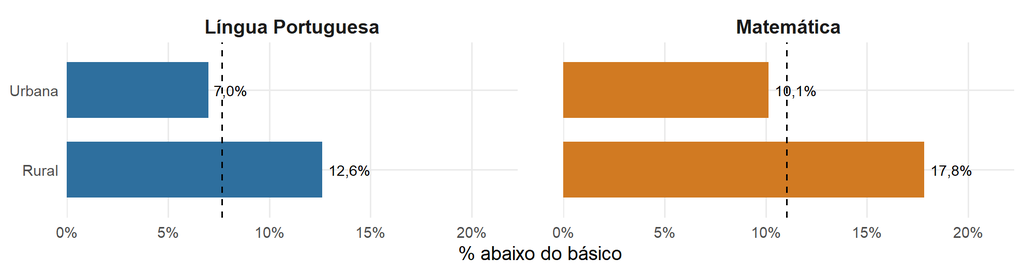

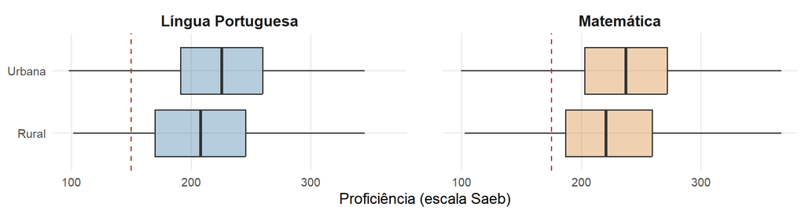

#### Rua asfaltada ★

*Na rua em que você mora tem: - Asfalto ou calçamento.* (`TX_RESP_Q11a`)

| Categoria | Alunos | % dos alunos | Abaixo do básico LP | Abaixo do básico MT |
| --- | --- | --- | --- | --- |
| Não | 2.056 | 22,7% | 12,4% | 17,9% |
| Sim | 7.006 | 77,3% | 6,3% | 9,0% |

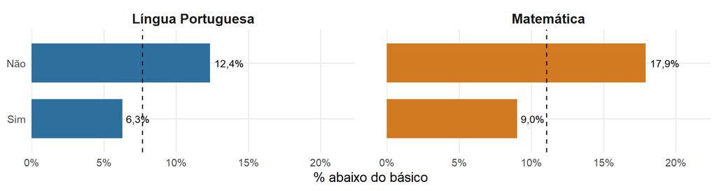

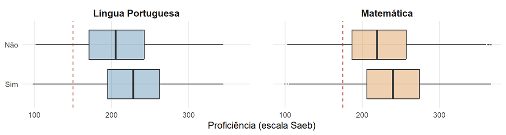

#### Água tratada

*Na rua em que você mora tem: - Água tratada.* (`TX_RESP_Q11b`)

| Categoria | Alunos | % dos alunos | Abaixo do básico LP | Abaixo do básico MT |
| --- | --- | --- | --- | --- |
| Não | 1.172 | 12,9% | 10,0% | 14,8% |
| Sim | 7.890 | 87,1% | 7,3% | 10,5% |

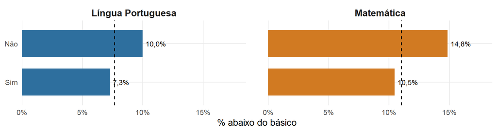

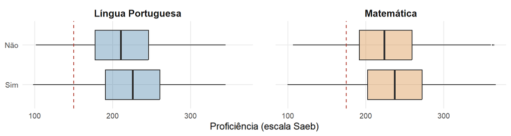

#### Iluminação na rua ★

*Na rua em que você mora tem: - Iluminação.* (`TX_RESP_Q11c`)

| Categoria | Alunos | % dos alunos | Abaixo do básico LP | Abaixo do básico MT |
| --- | --- | --- | --- | --- |
| Não | 489 | 5,4% | 12,9% | 20,2% |
| Sim | 8.573 | 94,6% | 7,4% | 10,5% |

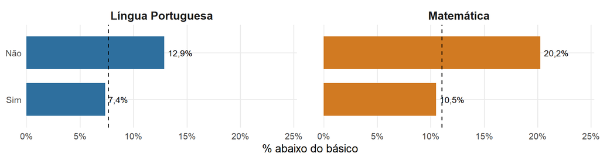

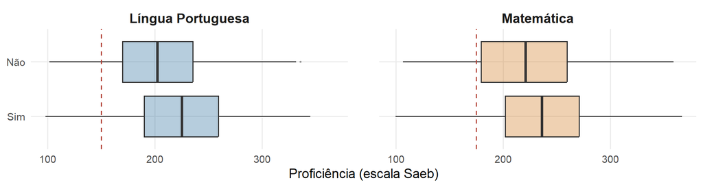

#### Celulares com internet em casa ★

*Dos itens relacionados abaixo, quantos existem na sua casa? - Celular com internet (smartphone).* (`TX_RESP_Q12g`)

| Categoria | Alunos | % dos alunos | Abaixo do básico LP | Abaixo do básico MT |
| --- | --- | --- | --- | --- |
| Nenhum | 201 | 2,2% | 21,4% | 31,8% |
| 1 | 766 | 8,5% | 12,8% | 22,2% |
| 2 | 1.435 | 15,8% | 9,3% | 12,8% |
| 3 ou mais | 6.660 | 73,5% | 6,3% | 8,8% |

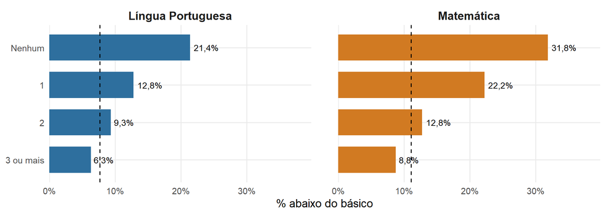

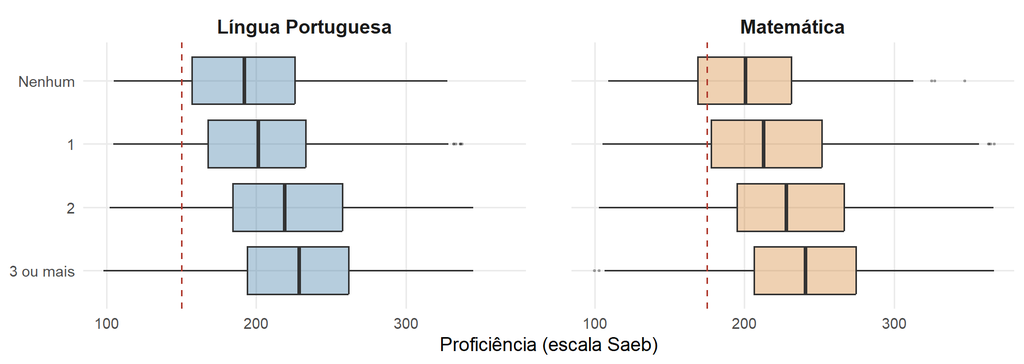

#### Wi-Fi em casa

*Na sua casa tem: - Rede Wi-Fi.* (`TX_RESP_Q13b`)

| Categoria | Alunos | % dos alunos | Abaixo do básico LP | Abaixo do básico MT |
| --- | --- | --- | --- | --- |
| Não | 759 | 8,4% | 17,5% | 22,1% |
| Sim | 8.303 | 91,6% | 6,8% | 10,0% |

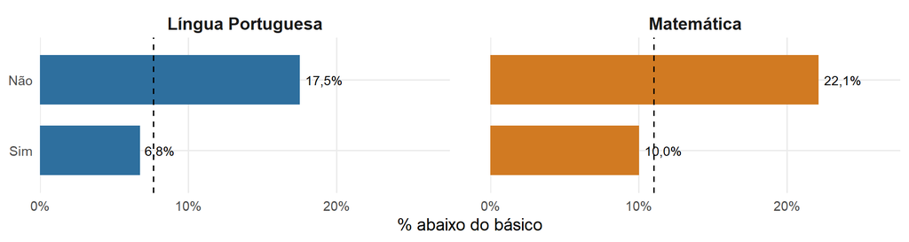

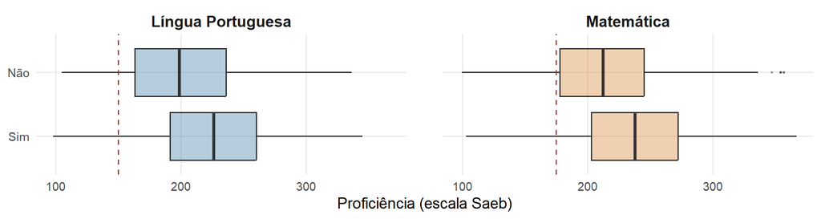

#### Meio de transporte para a escola

*Considerando a maior distância percorrida, normalmente de que forma você chega à sua escola?* (`TX_RESP_Q16`)

| Categoria | Alunos | % dos alunos | Abaixo do básico LP | Abaixo do básico MT |
| --- | --- | --- | --- | --- |
| À pé | 3.653 | 40,3% | 8,6% | 13,2% |
| De bicicleta | 638 | 7,0% | 11,3% | 11,9% |
| De Van (ou Kombi) | 693 | 7,6% | 4,5% | 5,8% |
| De ônibus | 1.550 | 17,1% | 8,8% | 13,8% |
| De metrô (ou trem urbano) | 7 | 0,1% | 71,4% | 57,1% |
| De carro | 1.750 | 19,3% | 4,1% | 5,4% |
| De barco | 34 | 0,4% | 23,5% | 23,5% |
| De motocicleta | 497 | 5,5% | 7,8% | 10,7% |
| Outro meio de transporte | 240 | 2,6% | 7,1% | 11,2% |

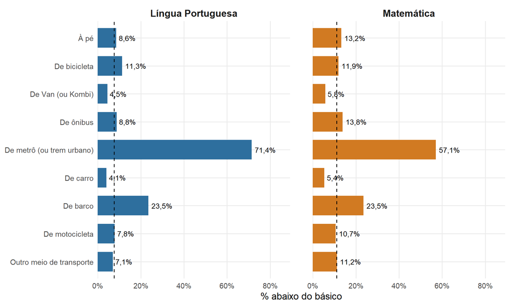

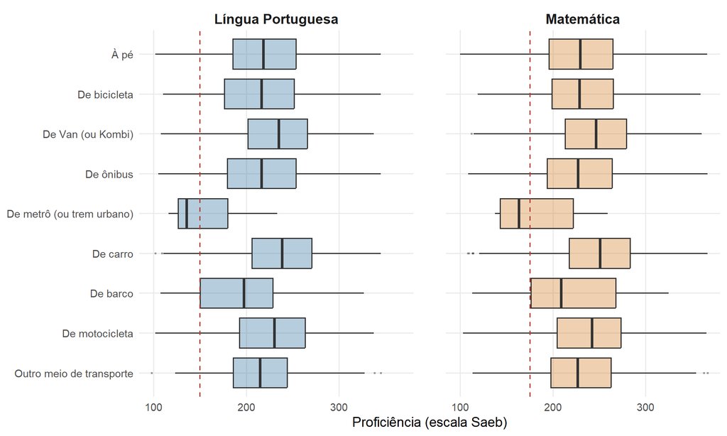

### 3.3.4 Responsáveis

#### Escolaridade da mãe ★

*Qual é a maior escolaridade da sua mãe (ou madastra ou mulher responsável por você)?* (`TX_RESP_Q08`)

| Categoria | Alunos | % dos alunos | Abaixo do básico LP | Abaixo do básico MT |
| --- | --- | --- | --- | --- |
| Não completou o 5º ano do Ensino Fundamental | 365 | 4,0% | 13,7% | 17,5% |
| Ensino Fundamental, até o 5º ano | 540 | 6,0% | 9,4% | 17,0% |
| Ensino Fundamental completo | 837 | 9,2% | 6,8% | 10,5% |
| Ensino Médio completo | 1.656 | 18,3% | 4,5% | 6,9% |
| Ensino Superior completo (faculdade ou graduação) | 1.304 | 14,4% | 3,7% | 4,1% |
| Não sei | 4.360 | 48,1% | 9,5% | 13,5% |

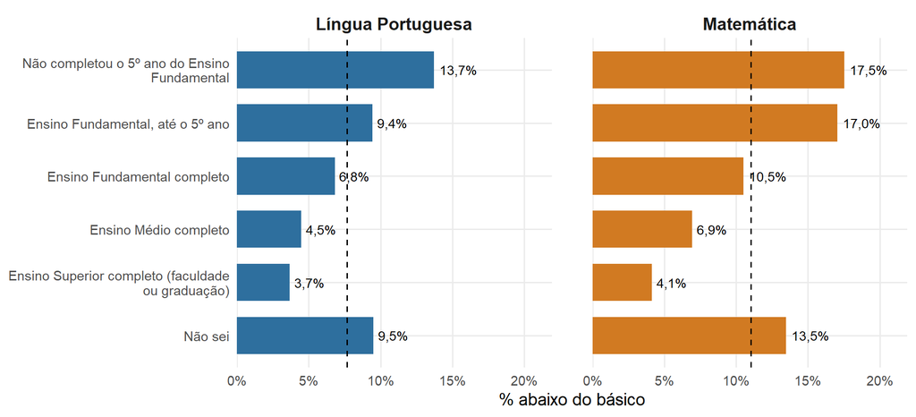

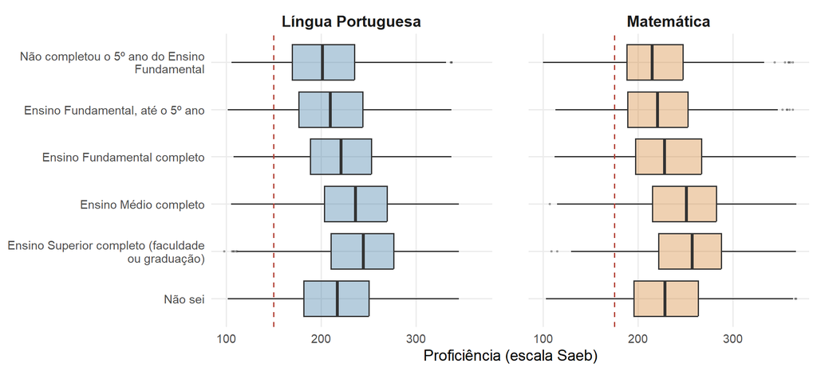

#### Escolaridade do pai ★

*Qual é a maior escolaridade de seu pai (ou padrasto homem responsável por você)?* (`TX_RESP_Q09`)

| Categoria | Alunos | % dos alunos | Abaixo do básico LP | Abaixo do básico MT |
| --- | --- | --- | --- | --- |
| Não completou o 5º ano do Ensino Fundamental | 460 | 5,1% | 10,4% | 13,3% |
| Ensino Fundamental, até o 5º ano | 545 | 6,0% | 6,6% | 12,3% |
| Ensino Fundamental completo | 639 | 7,1% | 8,8% | 11,7% |
| Ensino Médio completo | 1.282 | 14,1% | 5,1% | 6,9% |
| Ensino Superior completo (faculdade ou graduação) | 951 | 10,5% | 3,8% | 5,7% |
| Não sei | 5.185 | 57,2% | 8,7% | 12,6% |

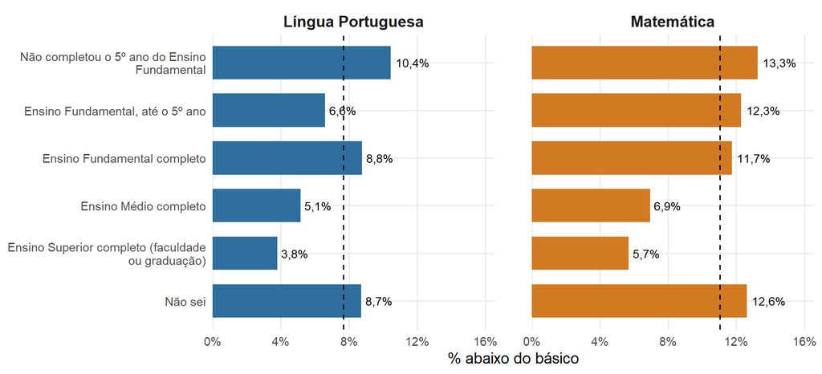

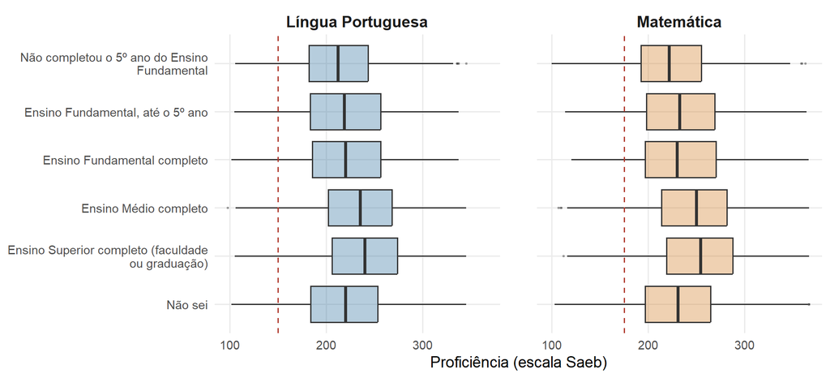

#### Leem em casa

*Com que frequência seus pais ou responsáveis costumam: - Ler em casa.* (`TX_RESP_Q10a`)

| Categoria | Alunos | % dos alunos | Abaixo do básico LP | Abaixo do básico MT |
| --- | --- | --- | --- | --- |
| Nunca ou quase nunca | 2.244 | 24,8% | 8,0% | 10,4% |
| De vez em quando | 4.920 | 54,3% | 6,7% | 10,2% |
| Sempre ou quase sempre | 1.898 | 20,9% | 9,6% | 14,0% |

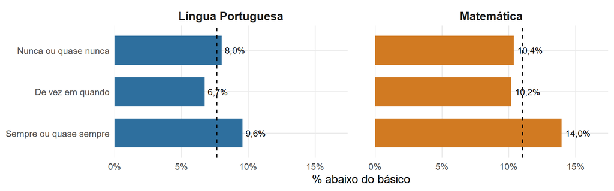

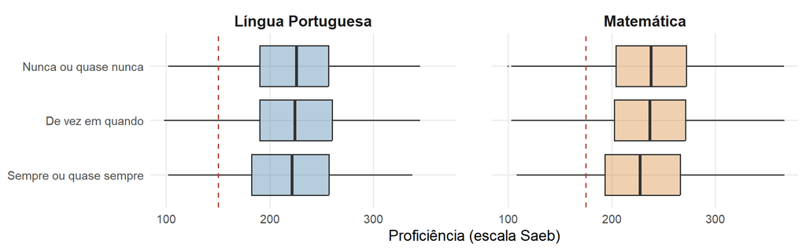

#### Incentivam a estudar ★

*Com que frequência seus pais ou responsáveis costumam: - Incentivar você a estudar.* (`TX_RESP_Q10c`)

| Categoria | Alunos | % dos alunos | Abaixo do básico LP | Abaixo do básico MT |
| --- | --- | --- | --- | --- |
| Nunca ou quase nunca | 360 | 4,0% | 14,7% | 18,3% |
| De vez em quando | 1.320 | 14,6% | 7,7% | 11,0% |
| Sempre ou quase sempre | 7.382 | 81,5% | 7,3% | 10,7% |

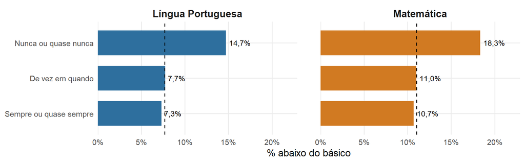

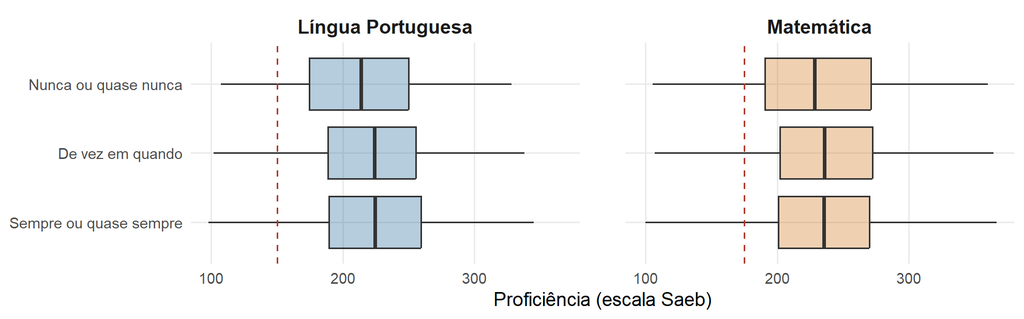

#### Incentivam a ir à aula ★

*Com que frequência seus pais ou responsáveis costumam: - Incentivar você a comparecer às aulas.* (`TX_RESP_Q10e`)

| Categoria | Alunos | % dos alunos | Abaixo do básico LP | Abaixo do básico MT |
| --- | --- | --- | --- | --- |
| Nunca ou quase nunca | 317 | 3,5% | 14,8% | 17,0% |
| De vez em quando | 643 | 7,1% | 13,5% | 17,1% |
| Sempre ou quase sempre | 8.102 | 89,4% | 6,9% | 10,3% |

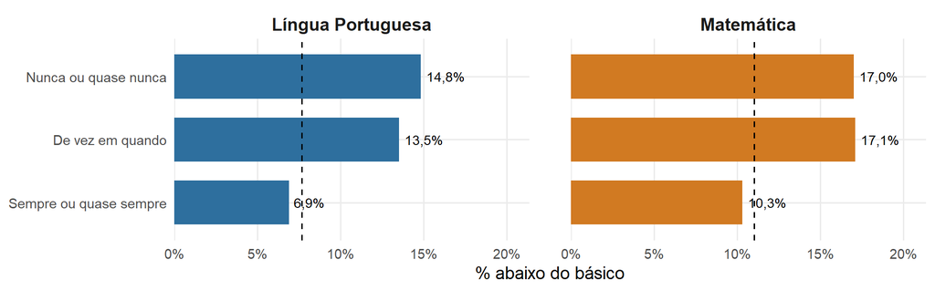

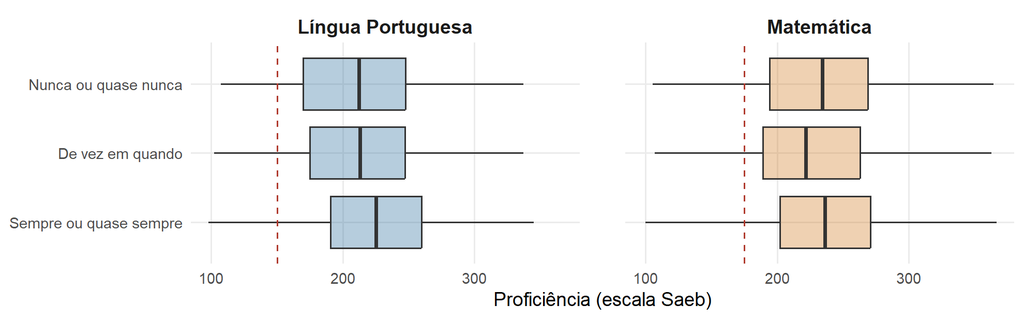

#### Vão às reuniões ★

*Com que frequência seus pais ou responsáveis costumam: - Ir às reuniões de pais na escola.* (`TX_RESP_Q10f`)

| Categoria | Alunos | % dos alunos | Abaixo do básico LP | Abaixo do básico MT |
| --- | --- | --- | --- | --- |
| Nunca ou quase nunca | 1.091 | 12,0% | 9,5% | 13,2% |
| De vez em quando | 2.851 | 31,5% | 7,7% | 11,1% |
| Sempre ou quase sempre | 5.120 | 56,5% | 7,2% | 10,5% |

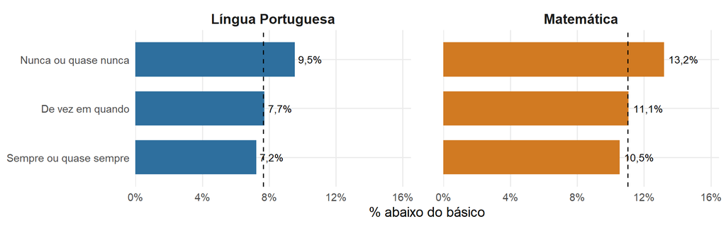

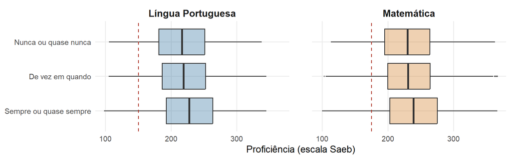

### 3.3.5 Rotina

#### Tempo de estudo

*Fora da escola em dias de aula, quanto tempo você usa para: - Estudar (lição de casa, trabalhos escolares, etc.).* (`TX_RESP_Q21a`)

| Categoria | Alunos | % dos alunos | Abaixo do básico LP | Abaixo do básico MT |
| --- | --- | --- | --- | --- |
| Não uso meu tempo para isso | 765 | 8,4% | 14,2% | 17,5% |
| Menos de 1 hora | 4.806 | 53,0% | 7,4% | 10,2% |
| Entre 1 e 2 horas | 2.800 | 30,9% | 5,0% | 8,5% |
| Mais de 2 horas | 691 | 7,6% | 12,9% | 20,1% |

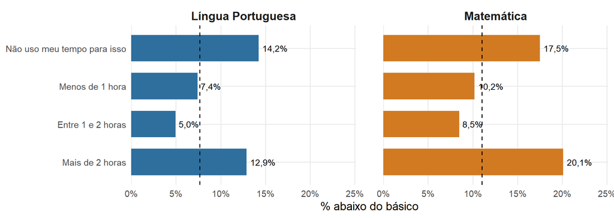

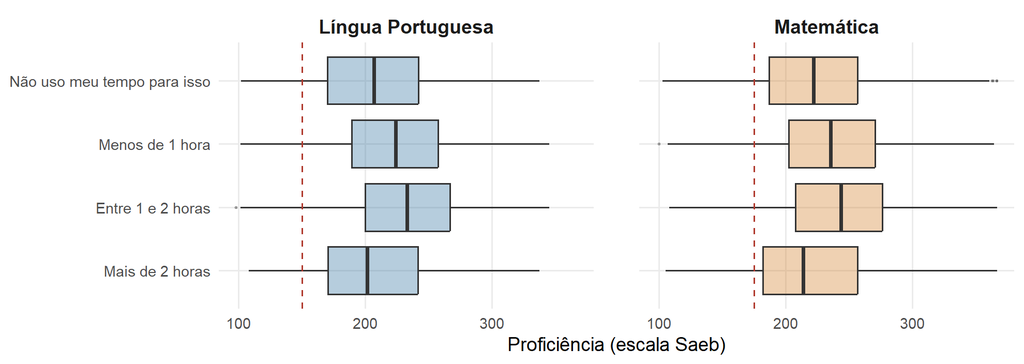

#### Cursos extracurriculares

*Fora da escola em dias de aula, quanto tempo você usa para: - Fazer cursos ou atividades extracurriculares (idioma, artes, informática etc.).* (`TX_RESP_Q21b`)

| Categoria | Alunos | % dos alunos | Abaixo do básico LP | Abaixo do básico MT |
| --- | --- | --- | --- | --- |
| Não uso meu tempo para isso | 5.266 | 58,1% | 8,5% | 11,8% |
| Menos de 1 hora | 1.706 | 18,8% | 6,6% | 10,0% |
| Entre 1 e 2 horas | 1.391 | 15,3% | 5,4% | 7,8% |
| Mais de 2 horas | 699 | 7,7% | 8,7% | 13,7% |

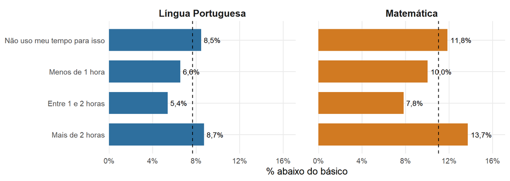

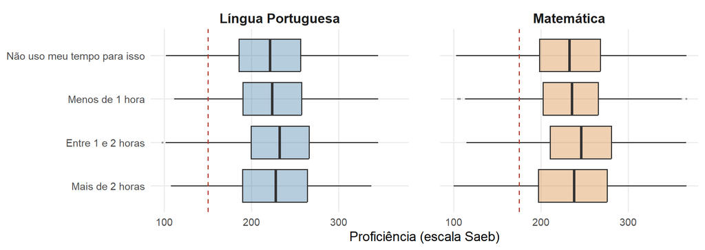

#### Trabalho em casa

*Fora da escola em dias de aula, quanto tempo você usa para: - Trabalhar em casa (lavar louça, limpar quintal, cuidar dos irmãos, etc.).* (`TX_RESP_Q21c`)

| Categoria | Alunos | % dos alunos | Abaixo do básico LP | Abaixo do básico MT |
| --- | --- | --- | --- | --- |
| Não uso meu tempo para isso | 1.170 | 12,9% | 10,9% | 13,9% |
| Menos de 1 hora | 3.566 | 39,4% | 7,2% | 10,0% |
| Entre 1 e 2 horas | 2.648 | 29,2% | 5,3% | 8,5% |
| Mais de 2 horas | 1.678 | 18,5% | 10,0% | 15,2% |

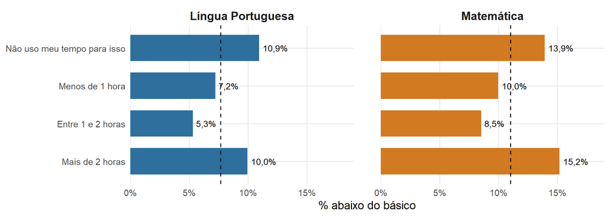

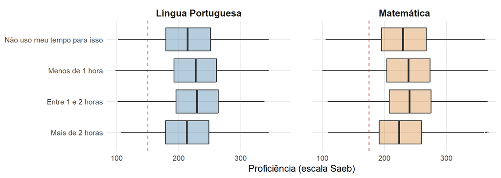

#### Trabalho fora de casa ★

*Fora da escola em dias de aula, quanto tempo você usa para: - Trabalhar fora de casa (recebendo ou não um salário).* (`TX_RESP_Q21d`)

| Categoria | Alunos | % dos alunos | Abaixo do básico LP | Abaixo do básico MT |
| --- | --- | --- | --- | --- |
| Não uso meu tempo para isso | 7.753 | 85,6% | 6,5% | 10,1% |
| Menos de 1 hora | 525 | 5,8% | 13,7% | 16,0% |
| Entre 1 e 2 horas | 319 | 3,5% | 15,7% | 16,0% |
| Mais de 2 horas | 465 | 5,1% | 14,4% | 17,0% |

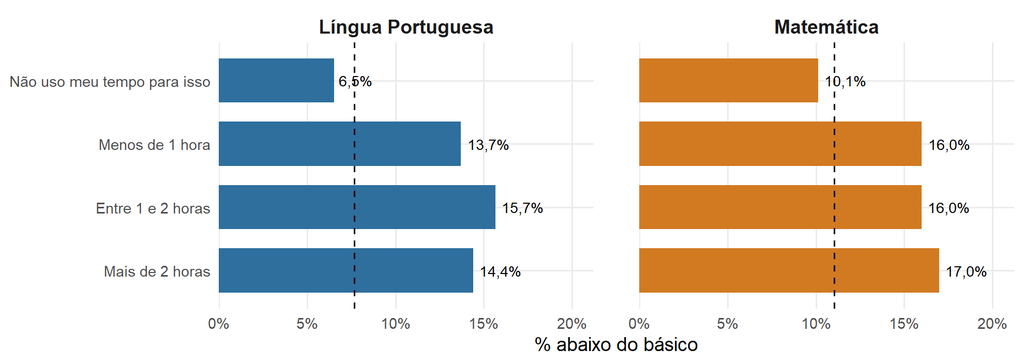

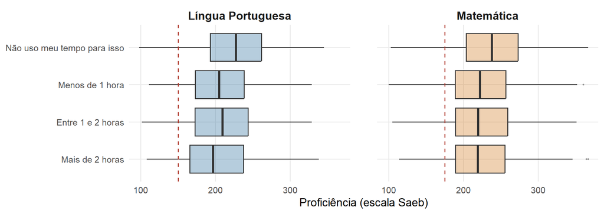

#### Lazer ★

*Fora da escola em dias de aula, quanto tempo você usa para: - Lazer (TV, brincar, internet, música etc.).* (`TX_RESP_Q21e`)

| Categoria | Alunos | % dos alunos | Abaixo do básico LP | Abaixo do básico MT |
| --- | --- | --- | --- | --- |
| Não uso meu tempo para isso | 282 | 3,1% | 23,4% | 29,1% |
| Menos de 1 hora | 1.105 | 12,2% | 12,9% | 17,8% |
| Entre 1 e 2 horas | 1.821 | 20,1% | 6,3% | 10,0% |
| Mais de 2 horas | 5.854 | 64,6% | 6,4% | 9,2% |

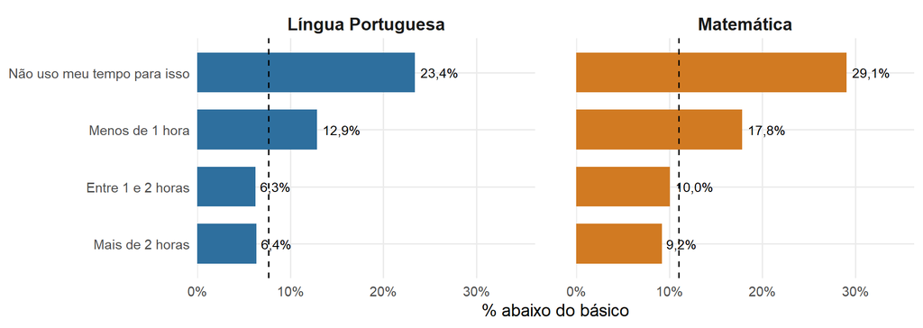

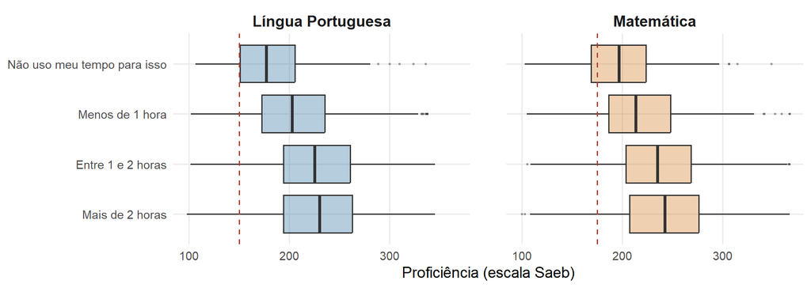

### 3.3.6 Escola e professores

#### Trabalhos em grupo ★

*Para os próximos itens, indique qual é a proporção de professores(as) da sua turma que abordam os seguintes temas em sala de aula: - Eles(as) desenvolvem trabalhos em grupos?* (`TX_RESP_Q22g`)

| Categoria | Alunos | % dos alunos | Abaixo do básico LP | Abaixo do básico MT |
| --- | --- | --- | --- | --- |
| Todos eles | 4.705 | 51,9% | 8,4% | 12,1% |
| A maior parte deles | 2.390 | 26,4% | 5,9% | 8,7% |
| Poucos deles | 1.594 | 17,6% | 6,4% | 9,2% |
| Nenhum deles | 373 | 4,1% | 15,5% | 21,2% |

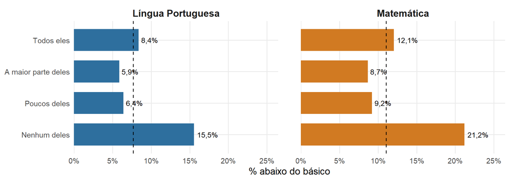

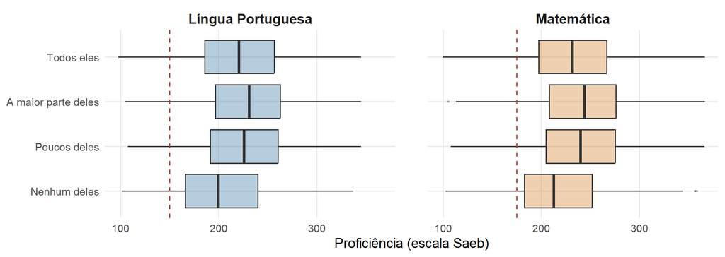

#### Interesse pelo conteúdo ★

*Sobre sua escola, indique o quanto você concorda ou discorda das afirmações abaixo: - Eu me interesso sobre o que foi ensinado na escola neste ano.* (`TX_RESP_Q23a`)

| Categoria | Alunos | % dos alunos | Abaixo do básico LP | Abaixo do básico MT |
| --- | --- | --- | --- | --- |
| Concordo totalmente | 4.687 | 51,7% | 8,0% | 11,4% |
| Concordo | 3.998 | 44,1% | 6,5% | 9,8% |
| Discordo | 234 | 2,6% | 11,5% | 15,0% |
| Discordo totalmente | 143 | 1,6% | 23,1% | 27,3% |

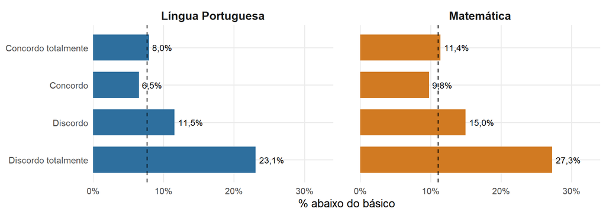

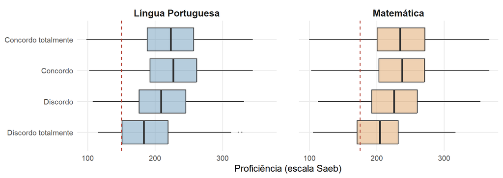

#### Professores motivam ★

*Sobre sua escola, indique o quanto você concorda ou discorda das afirmações abaixo: -Meus (Minhas) professores(as) me motivam a continuar meus estudos.* (`TX_RESP_Q23i`)

| Categoria | Alunos | % dos alunos | Abaixo do básico LP | Abaixo do básico MT |
| --- | --- | --- | --- | --- |
| Concordo totalmente | 6.260 | 69,1% | 6,5% | 10,0% |
| Concordo | 2.415 | 26,6% | 8,8% | 11,8% |
| Discordo | 223 | 2,5% | 16,6% | 19,7% |
| Discordo totalmente | 164 | 1,8% | 20,7% | 25,0% |

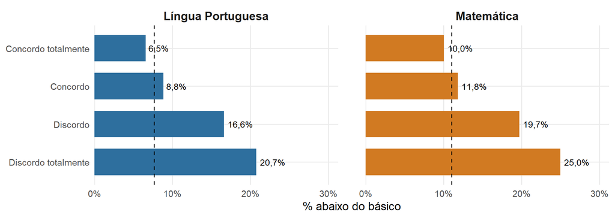

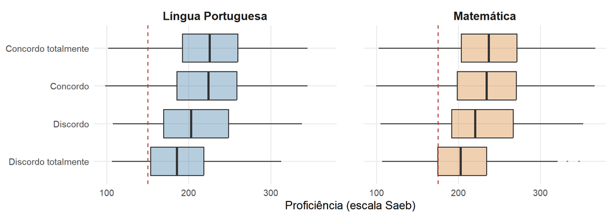

#### Professores acreditam que é capaz ★

*Sobre sua escola, indique o quanto você concorda ou discorda das afirmações abaixo: -Meus (Minhas) professores(as) acreditam que eu sou capaz de aprender.* (`TX_RESP_Q23h`)

| Categoria | Alunos | % dos alunos | Abaixo do básico LP | Abaixo do básico MT |
| --- | --- | --- | --- | --- |
| Concordo totalmente | 6.302 | 69,5% | 6,2% | 9,6% |
| Concordo | 2.426 | 26,8% | 9,7% | 13,1% |
| Discordo | 202 | 2,2% | 14,9% | 19,8% |
| Discordo totalmente | 132 | 1,5% | 27,3% | 28,0% |

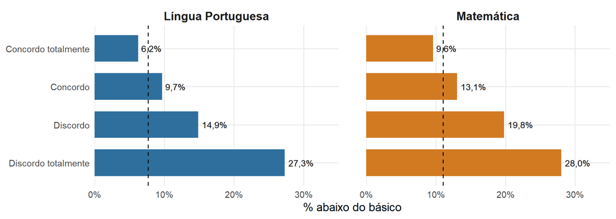

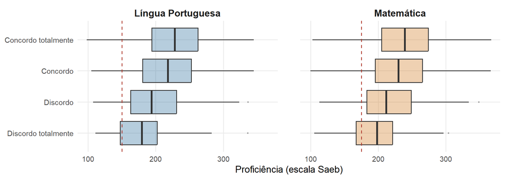

#### Segurança na escola

*Sobre sua escola, indique o quanto você concorda ou discorda das afirmações abaixo: - Eu me sinto seguro(a) quando estou na escola.* (`TX_RESP_Q23d`)

| Categoria | Alunos | % dos alunos | Abaixo do básico LP | Abaixo do básico MT |
| --- | --- | --- | --- | --- |
| Concordo totalmente | 3.915 | 43,2% | 7,8% | 11,6% |
| Concordo | 3.487 | 38,5% | 7,0% | 10,3% |
| Discordo | 1.174 | 13,0% | 7,2% | 10,6% |
| Discordo totalmente | 486 | 5,4% | 12,1% | 13,4% |

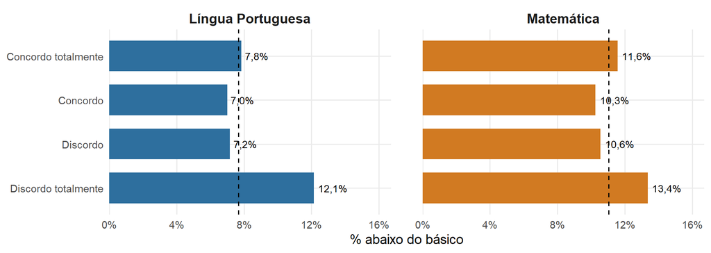

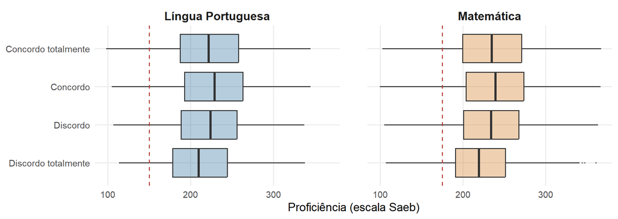

# 4 Curitiba × Brasil

## 4.1 Visão geral

Os alunos de Curitiba têm, em média, notas cerca de 10 pontos mais altas que os do Brasil nas duas disciplinas, e a proporção abaixo do nível básico é menor: 4,2% em LP, dentro da expectativa de 5%, e 6,8% em MT.

| Grupo | Alunos | Média LP | Média MT | Abaixo do básico LP | Abaixo do básico MT |
| --- | --- | --- | --- | --- | --- |
| Brasil | 9.062 | 223,4 | 236,3 | 7,7% | 11,0% |
| Curitiba | 4.452 | 233,4 | 246,3 | 4,2% | 6,8% |

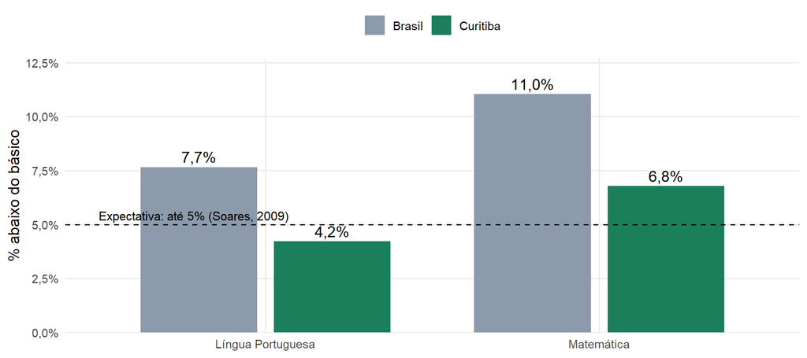

## 4.2 Trajetória escolar e escolaridade da família

Os gráficos abaixo comparam a proporção de alunos abaixo do nível básico em Curitiba e no Brasil segundo o número de reprovações do aluno e a escolaridade da mãe. Categorias com menos de 30 alunos aparecem como “n < 30”.

### 4.2.1 Reprovação

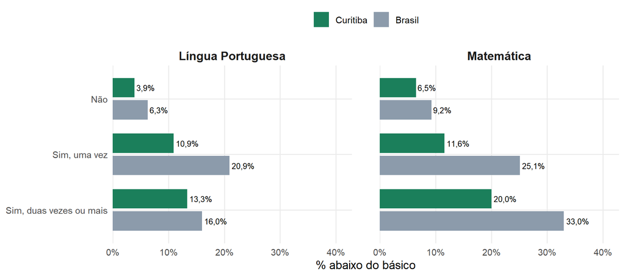

### 4.2.2 Escolaridade da mãe

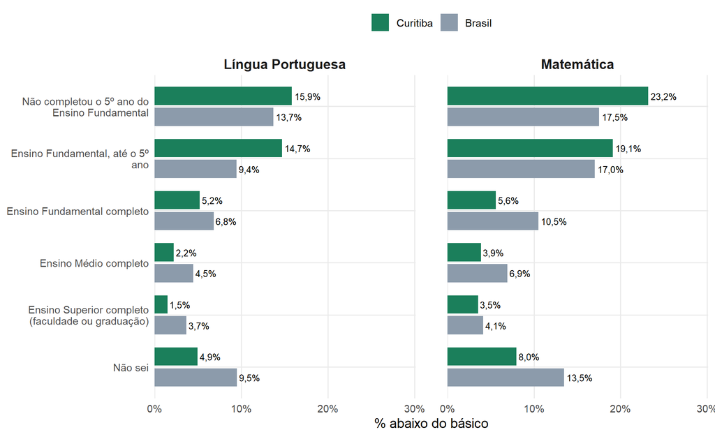

## 4.3 Principais diferenças

> Rascunho para revisão do grupo.
- Reprovação: é fortemente associada a estar abaixo do básico nos dois grupos, mas em Curitiba a proporção entre os reprovados é bem menor que no Brasil (cerca de metade entre os reprovados uma vez).
- Escolaridade da mãe: em Curitiba, filhos de mães com baixa escolaridade apresentam proporções abaixo do básico semelhantes ou maiores que no Brasil, apesar do desempenho médio superior, o que pode indicar desigualdade interna. Esses grupos são pequenos e o resultado deve ser visto com cautela.
- Composição socioeconômica: os alunos de Curitiba concentram-se nos níveis mais altos do INSE, e parte da vantagem da cidade parece acompanhar esse perfil (ver `R/06 Comparação Curitiba.R`).

# 5 Fatores associados a estar abaixo do nível básico

Para comparar a força da associação de cada variável selecionada pelo grupo com estar abaixo do nível básico, foi usado o V de Cramér, calculado a partir do teste qui-quadrado de independência. Ele varia de 0 (nenhuma associação) a 1 (associação perfeita); como referência usual, valores próximos de 0,1 indicam associação fraca e próximos de 0,3, moderada.

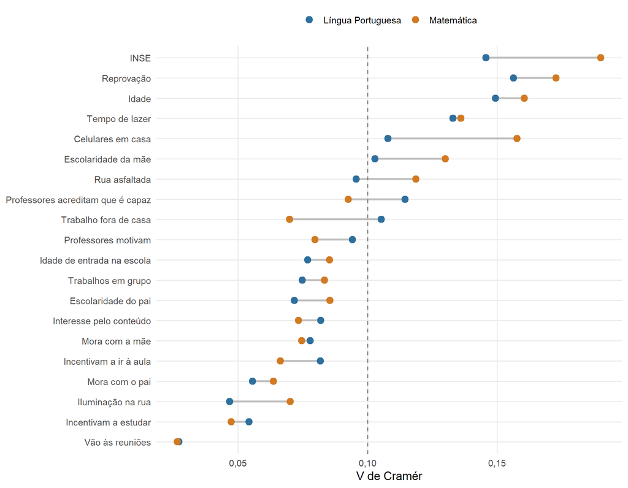

| Bloco | Variável | V (LP) | p-valor (LP) | V (MT) | p-valor (MT) |
| --- | --- | --- | --- | --- | --- |
| Nível socioeconômico | INSE | 0,146 | < 0,001 | 0,190 | < 0,001 |
| Trajetória escolar | Reprovação | 0,156 | < 0,001 | 0,173 | < 0,001 |
| Trajetória escolar | Idade | 0,149 | < 0,001 | 0,160 | < 0,001 |
| Rotina | Tempo de lazer | 0,133 | < 0,001 | 0,136 | < 0,001 |
| Nível socioeconômico | Celulares em casa | 0,108 | < 0,001 | 0,158 | < 0,001 |
| Nível socioeconômico | Escolaridade da mãe | 0,103 | < 0,001 | 0,130 | < 0,001 |
| Entorno | Rua asfaltada | 0,096 | < 0,001 | 0,119 | < 0,001 |
| Escola | Professores acreditam que é capaz | 0,114 | < 0,001 | 0,093 | < 0,001 |
| Rotina | Trabalho fora de casa | 0,105 | < 0,001 | 0,070 | < 0,001 |
| Escola | Professores motivam | 0,094 | < 0,001 | 0,080 | < 0,001 |
| Trajetória escolar | Idade de entrada na escola | 0,077 | < 0,001 | 0,085 | < 0,001 |
| Escola | Trabalhos em grupo | 0,075 | < 0,001 | 0,083 | < 0,001 |
| Nível socioeconômico | Escolaridade do pai | 0,072 | < 0,001 | 0,086 | < 0,001 |
| Escola | Interesse pelo conteúdo | 0,082 | < 0,001 | 0,073 | < 0,001 |
| Estrutura familiar | Mora com a mãe | 0,078 | < 0,001 | 0,075 | < 0,001 |
| Envolvimento dos pais | Incentivam a ir à aula | 0,082 | < 0,001 | 0,066 | < 0,001 |
| Estrutura familiar | Mora com o pai | 0,056 | < 0,001 | 0,064 | < 0,001 |
| Entorno | Iluminação na rua | 0,047 | < 0,001 | 0,070 | < 0,001 |
| Envolvimento dos pais | Incentivam a estudar | 0,054 | < 0,001 | 0,047 | < 0,001 |
| Envolvimento dos pais | Vão às reuniões | 0,027 | 0,034 | 0,027 | 0,040 |

Força média da associação por bloco:

| Bloco | Variáveis | V médio (LP) | V médio (MT) |
| --- | --- | --- | --- |
| Trajetória escolar | 3 | 0,128 | 0,139 |
| Nível socioeconômico | 4 | 0,107 | 0,141 |
| Rotina | 2 | 0,119 | 0,103 |
| Escola | 4 | 0,091 | 0,082 |
| Entorno | 2 | 0,071 | 0,094 |
| Estrutura familiar | 2 | 0,067 | 0,069 |
| Envolvimento dos pais | 3 | 0,055 | 0,047 |

> Rascunho para revisão do grupo. Todas as variáveis selecionadas apresentam associação estatisticamente significativa com estar abaixo do nível básico, mas de intensidade fraca (V entre 0,03 e 0,19), o que é esperado quando o evento estudado é pouco frequente. As associações mais fortes estão na trajetória escolar (reprovação e idade) e no nível socioeconômico (INSE, bens e escolaridade da mãe), seguidas do tempo de lazer. O envolvimento dos pais aparece com as associações mais fracas. Como essas medidas olham cada variável isoladamente, parte delas pode refletir o efeito de outras (por exemplo, do nível socioeconômico); a separação desses efeitos será feita na etapa de modelagem.

# 6 Síntese preliminar

> Rascunho para revisão do grupo.
1. Na amostra Brasil, 7,7% dos alunos do 5º ano estão abaixo do nível básico em Língua Portuguesa e 11,0% em Matemática, acima da expectativa de 5% — e esses valores provavelmente subestimam a realidade, devido ao filtro de questionário completo.
2. Curitiba apresenta desempenho superior ao do Brasil, mas grande parte dessa diferença acompanha o perfil socioeconômico mais alto de seus alunos.
3. Os fatores mais associados a estar abaixo do básico são a reprovação, a distorção idade-série e o nível socioeconômico.

# 7 Próximos passos

- Selecionar as análises e visualizações mais relevantes para a versão final.
- Verificar se os principais fatores continuam associados ao desempenho entre alunos de mesmo nível socioeconômico.
- Ajustar modelos de regressão logística para `abaixo_LP` e `abaixo_MT`, avaliando-os na base de teste.

# 8 Referências

> Completar com as referências completas usadas pelo grupo.
- INEP. *Microdados do Saeb 2023*. Brasília: Inep. Disponível em: https://download.inep.gov.br/microdados/microdados_saeb_2023.zip.
- SOARES, J. F. (2009) — fonte do Quadro 1 de níveis de aprendizado; completar a referência.